# TEST2_R

John Horton

December 3, 2015

Setup:

```r
#Load required packages
require(ggplot2)
require(grid)
require(plyr)
#Load required dataframes
abalone <- read.csv("http://archive.ics.uci.edu/ml/machine-learning-databases/abalone/abalone.data",header = FALSE)
names(abalone) <- c("sex", "length", "diameter", "height", "weight.whole", "weight.shucked", "weight.viscera", "weight.shell", "rings")
data(diamonds)
data(faithful)
```

Question 1:

```r
#The vector sample sizes holds the specified sample percentages
sampleSizes <- c(0.01,0.10,0.25,0.50,0.80,1.00)
#We initialize the list sampleFrame to hold each sample
sampleFrame <- list()
#The dataframe sampleStats is generated with 6 columns and 4 rows, as per the prompt
sampleStats <- data.frame(matrix(ncol=6,nrow=4))
#The columns of sampleStats are named as per the prompt
names(sampleStats) <- paste(sampleSizes*100,"%",sep="")
#The rows of sampleStats are named as per the prompt
row.names(sampleStats) <- c("SampleMin","SampleMax","SampleMean","SampleVar")
#We now loop through each column in sampleStats to generate a sample containing that column's percentage of the original dataset
for(i in 1:ncol(sampleStats)){
  #We now take a sample of the current size
  sampleFrame[[i]] <- abalone[sample(nrow(abalone),sampleSizes[i]*nrow(abalone)),]
  #Now that we have our sample, we loop through each row in sampleStats to take the desired summary statistic
  for(j in 1:nrow(sampleStats)){
    #Min, Max, Mean, and Variance are placed in their appropriate rows
    if(j==1){
      sampleStats[j,i] <- min(sampleFrame[[i]]$weight.whole)
    } else if(j==2){
      sampleStats[j,i] <- max(sampleFrame[[i]]$weight.whole)
    } else if(j==3){
      sampleStats[j,i] <- mean(sampleFrame[[i]]$weight.whole)
    } else if(j==4){
      sampleStats[j,i] <- var(sampleFrame[[i]]$weight.whole)
    }
  }
}
#Prints the dataframe of summary statistics for the samples
print(sampleStats)
```

```
##                   1%       10%       25%       50%       80%      100%
## SampleMin  0.0835000 0.0140000 0.0020000 0.0020000 0.0020000 0.0020000
## SampleMax  2.7795000 2.2500000 2.4925000 2.8255000 2.8255000 2.8255000
## SampleMean 0.8583293 0.8155839 0.8310771 0.8302093 0.8294187 0.8287422
## SampleVar  0.3108470 0.2399534 0.2397953 0.2385738 0.2418982 0.2404814
```

Question 2:

The function samplePlots is designed to take a list of dataframes from the user and then produce a grid of histograms of the specified column for each of those dataframes. Each plot is titled according to a list of titles passed by the user. This function is designed specifically for use in this test.

Parameters: - dataFrames: the list of dataframes passed by the user - myColTitles: the titles of the column of which the user would like a histogram for each dataframe - myTitles: the list of titles for each histogram

[output not shown]

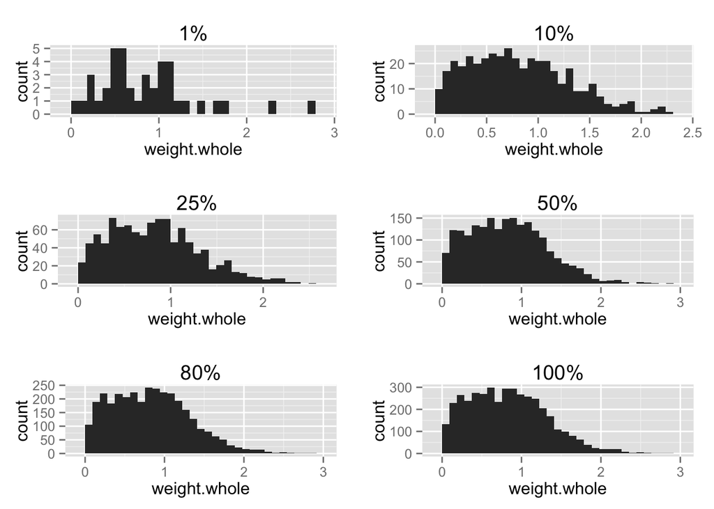

```r
samplePlots <- function(dataFrames,myColTitles,myTitles){
  #We initialize the list sampleHisto to hold a histogram for each sample
  sampleHisto <- list()
  #We create a grid to hold those six histograms
  pushViewport(viewport(layout=grid.layout(3,2)))
  #We loop through each dataframe in dataFrames so that we may generate all of the desired histograms
  for(i in 1:length(dataFrames)){
    #We create the datframe currentFrame so that ggplot may recognize it (it cannot recognize elements of a list, even if they are dataframes)
    currentFrame = data.frame(dataFrames[[i]])
    #We specify the column of currentFrame which we would like to plot in this histogram
    currentTitle = myColTitles[i]
    #We add to our list of histograms a new histogram of the current dataframe, along with a title so we may keep track of which plot corresponds to which sample
    sampleHisto[[i]] <- ggplot(currentFrame,aes_string(currentTitle)) + geom_histogram() + ggtitle(paste(myTitles[i]*100,"%",sep=""))
  }
  #The index variable i is initialized to keep track of which sample plot we must next place in the grid
  i <- 1
  #We loop through each row and column in our grid to fill the grid with the plots we generated above
  for(j in 1:3){
    for(k in 1:2){
      #Plots are added to the grid
      print(sampleHisto[[i]],vp=viewport(layout.pos.row=j,layout.pos.col=k))
      #We increase i by 1 to move on to the next plot
      i <- i+1
    }
  }
}
#Generates the histograms as per the prompt and prints them
samplePlots(sampleFrame,rep("weight.whole",6),sampleSizes)
```

Question 3:

```r
#The vector loopSizes holds all sample sizes given in sampleSizes that are less than 1.00 (100%)
loopSizes <- sampleSizes[sampleSizes<1.00]
#The dataframe loopMeans is generated with 5 columns and 1000 rows, as per the prompt
loopMeans <- data.frame(matrix(ncol=5,nrow=1000))
#The columns of loopMeans are named as per the prompt
names(loopMeans) <- c("SampleMean1Pct","SampleMean10Pct","SampleMean25Pct","SampleMean50Pct","SampleMean80Pct")
#We now loop through each column in loopMeans to generate a sample containing that column's percentage of the original dataset
for(i in 1:length(loopSizes)){
  #We loop over the range 1:1000 to generate 1000 samples of each size
  for(j in 1:1000){
    #We now take a sample of the current size
    sampleFrame <- abalone[sample(nrow(abalone),loopSizes[i]*nrow(abalone)),]
    #The current sample mean is placed in its appropriate row
    loopMeans[j,i] <- mean(sampleFrame$weight.whole)
  }
}
#Prints the dataframe containing the sample means for all samples of each size
print(loopMeans)
```

```
##      SampleMean1Pct SampleMean10Pct SampleMean25Pct SampleMean50Pct
## 1         0.6427805       0.8269856       0.8142629       0.8303752
## 2         0.9426585       0.8770324       0.7928683       0.8290256
## 3         0.7505610       0.8312434       0.8021624       0.8359430
## 4         0.7093049       0.8689832       0.8212711       0.8338709
## 5         0.7411463       0.8489844       0.8440867       0.8316054
## 6         0.6161220       0.8595180       0.8509353       0.8274670
## 7         0.8363049       0.8477002       0.8357414       0.8360728
## 8         0.8534268       0.8726079       0.8112701       0.8183999
## 9         0.7926951       0.8391043       0.8361700       0.8335409
## 10        0.8687195       0.7943993       0.8413166       0.8217100
## 11        0.7005854       0.8354952       0.8057227       0.8258987
## 12        0.8306951       0.8140767       0.8397534       0.8231633
## 13        0.8484390       0.7916523       0.8349061       0.8373872
## 14        0.7275854       0.8532746       0.8142687       0.8338190
```

[output cut: 1987 more lines]

Question 4:

```
## stat_bin: binwidth defaulted to range/30. Use 'binwidth = x' to adjust this.
```

```
## stat_bin: binwidth defaulted to range/30. Use 'binwidth = x' to adjust this.
## stat_bin: binwidth defaulted to range/30. Use 'binwidth = x' to adjust this.
```

```
## stat_bin: binwidth defaulted to range/30. Use 'binwidth = x' to adjust this.
## stat_bin: binwidth defaulted to range/30. Use 'binwidth = x' to adjust this.
```

```
## stat_bin: binwidth defaulted to range/30. Use 'binwidth = x' to adjust this.
```

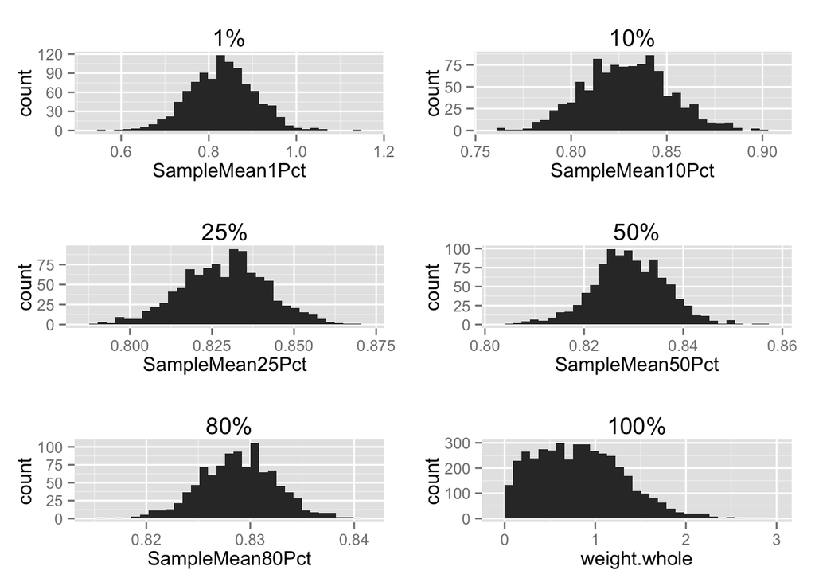

```r
#So that we may use our function from Question 2, we must create the list loopFrame to hold a separate dataframe for each histogram
loopFrame <- list()
#The index variable i is initialized to keep track of which dataframe we are entering in our list
i <- 1
#The first 5 dataframes in our list are simply loopMeans itself, as the first 5 histograms are plots of those 5 sets of sample means
for(j in 1:ncol(loopMeans)){
  loopFrame[[j]] <- loopMeans
  i <- i+1
}
#The final dataframe is abalone itself, as the final histogram is a plot of the total dataset
loopFrame[[i]] <- abalone
#We create a list of titles to feed the function, so that each plot contains the proper set of sample means
titleList = c("SampleMean1Pct","SampleMean10Pct","SampleMean25Pct","SampleMean50Pct","SampleMean80Pct","weight.whole")
#Now that our setup is complete, we call samplePlots
samplePlots(loopFrame,titleList,sampleSizes)
```

Question 5:

```r
#The dataframe loopStats is generated with 6 columns and 4 rows; the 6 columns are for each sample size, and the 4 rows are for each of the summary statistics as above
loopStats <- data.frame(matrix(ncol=6,nrow=4))
#The columns of loopStats are named as above
names(loopStats) <- paste(sampleSizes*100,"%",sep="")
#The rows of loopStats are named appropriately, as they are now summary statistics of our sets of sample means
row.names(loopStats) <- c("MinOfMeans","MaxOfMeans","ReSampleMean","VarOfMeans")
#We loop through each sample size in loopSizes (each of the original sample sizes that is less than 1.00, or 100%) so we may take the appropriate summary statstics for each set of sample means
for(i in 1:length(loopSizes)){
  #We loop through each row in loopStats to take the desired summary statistic
  for(j in 1:nrow(loopStats)){
    #Min, Max, Mean, and Variance are placed in their appropriate rows
    if(j==1){
      loopStats[j,i] <- min(loopMeans[,i])
    } else if(j==2){
      loopStats[j,i] <- max(loopMeans[,i])
    } else if(j==3){
      loopStats[j,i] <- mean(loopMeans[,i])
    } else if(j==4){
      loopStats[j,i] <- var(loopMeans[,i])
    }
  }
}
#We now add the final column, that for the 1.00 (100%) sample
for(j in 1:nrow(loopStats)){
  #We take the desired summary statistics below; note here that each of these statistics, except for variance, is simply equal to the mean of the entire dataset, as the sample mean for a sample size of 1.00 (100%) is simply the mean of the entire dataset; the variance is zero as all sample means of a full sample are equal to the mean of the entire dataset, as above
  if(j==1){
    loopStats[j,6] <- min(sampleStats[3,6])
  } else if(j==2){
    loopStats[j,6] <- max(sampleStats[3,6])
  } else if(j==3){
    loopStats[j,6] <- mean(sampleStats[3,6])
  } else if(j==4){
    loopStats[j,6] <- 0
  }
}
#We append the summary statistics for our sample means to the original dataframe of summary statstics for the samples themselves, and print that dataframe
sampleStats <- rbind(sampleStats,loopStats)
print(sampleStats)
```

```
##                       1%          10%          25%          50%
## SampleMin    0.083500000 0.0140000000 0.0020000000 2.000000e-03
## SampleMax    2.779500000 2.2500000000 2.4925000000 2.825500e+00
## SampleMean   0.858329268 0.8155839329 0.8310771073 8.302093e-01
## SampleVar    0.310846995 0.2399534184 0.2397953160 2.385738e-01
## MinOfMeans   0.554085366 0.7617529976 0.7886652299 8.054600e-01
## MaxOfMeans   1.138268293 0.8992889688 0.8687600575 8.571063e-01
## ReSampleMean 0.830479744 0.8290272422 0.8287854401 8.290928e-01
## VarOfMeans   0.005493728 0.0004940573 0.0001719222 5.541783e-05
##                       80%      100%
## SampleMin    2.000000e-03 0.0020000
## SampleMax    2.825500e+00 2.8255000
## SampleMean   8.294187e-01 0.8287422
## SampleVar    2.418982e-01 0.2404814
## MinOfMeans   8.160025e-01 0.8287422
## MaxOfMeans   8.406329e-01 0.8287422
## ReSampleMean 8.288603e-01 0.8287422
## VarOfMeans   1.334945e-05 0.0000000
```

Question 6:

```
## stat_bin: binwidth defaulted to range/30. Use 'binwidth = x' to adjust this.
```

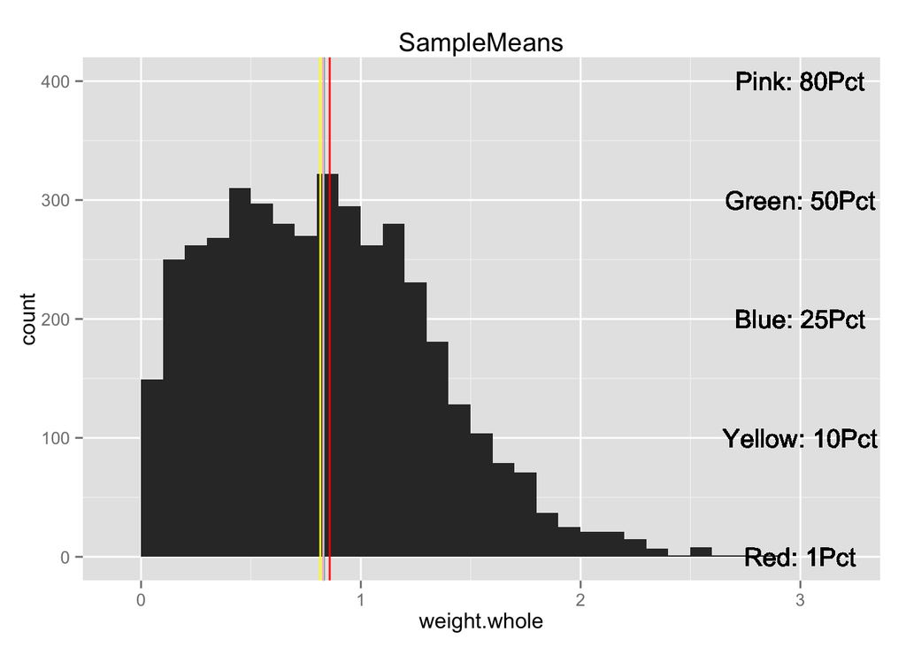

```r
#Here we generate a single plot containing a histogram of the entire dataset overlaid with lines representing the 1%, 10%, 25%, 50%, and 80% sample means; lines are created using geom_vline and labeled using geom_text; note that labels are off to the side as the lines are so close together that labeling on or near the line would cloud the plot
sampleMeanHisto <- ggplot(abalone,aes_string("weight.whole")) + geom_histogram() +
  ggtitle("SampleMeans") + geom_vline(xintercept=sampleStats[3,1],color="red") +
  geom_vline(xintercept=sampleStats[3,2],color="yellow") +
  geom_vline(xintercept=sampleStats[3,3],color="blue") +
  geom_vline(xintercept=sampleStats[3,4],color="green") +
  geom_vline(xintercept=sampleStats[3,5],color="pink") +
  geom_text(aes(3,0,label="Red: 1Pct")) +
  geom_text(aes(3,100,label="Yellow: 10Pct")) +
  geom_text(aes(3,200,label="Blue: 25Pct")) +
  geom_text(aes(3,300,label="Green: 50Pct")) +
  geom_text(aes(3,400,label="Pink: 80Pct")) +
  theme(legend.position="none")
print(sampleMeanHisto)
```

Question 7:

```
## stat_bin: binwidth defaulted to range/30. Use 'binwidth = x' to adjust this.
```

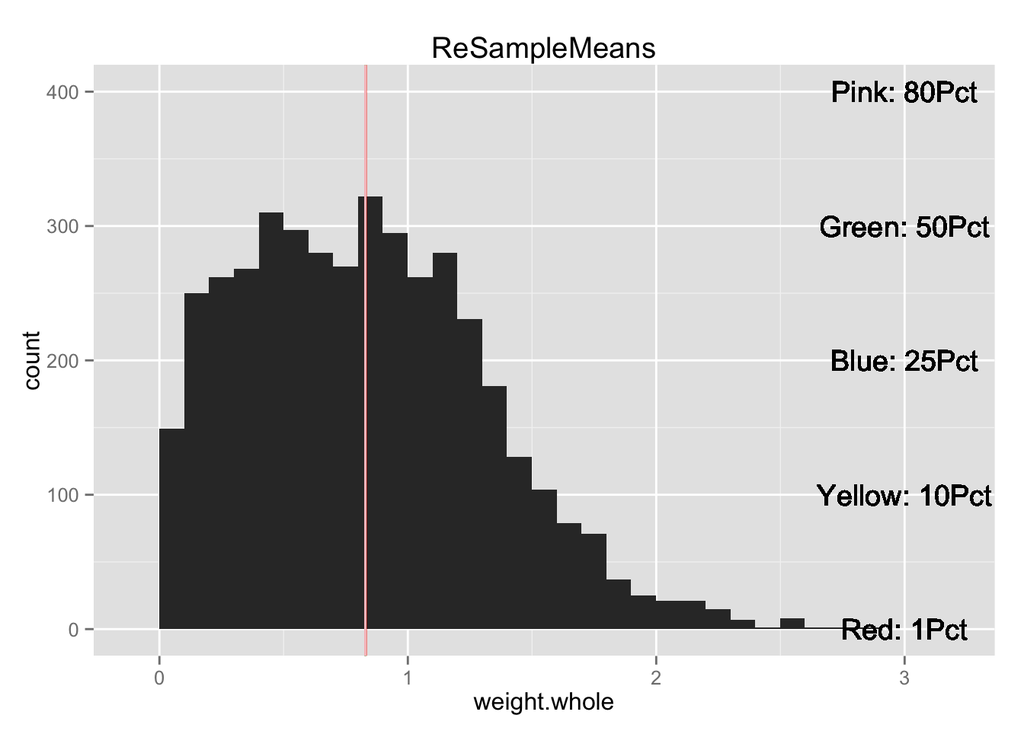

```r
#Here we generate the same plot as above, this time overlaying lines representing the appropriate resample means rather than the sample means; lines are generated and labeled as above
reSampleMeanHisto <- ggplot(abalone,aes_string("weight.whole")) + geom_histogram() +
  ggtitle("ReSampleMeans") + geom_vline(xintercept=sampleStats[7,1],color="red") +
  geom_vline(xintercept=sampleStats[7,2],color="yellow") +
  geom_vline(xintercept=sampleStats[7,3],color="blue") +
  geom_vline(xintercept=sampleStats[7,4],color="green") +
  geom_vline(xintercept=sampleStats[7,5],color="pink") +
  geom_text(aes(3,0,label="Red: 1Pct")) +
  geom_text(aes(3,100,label="Yellow: 10Pct")) +
  geom_text(aes(3,200,label="Blue: 25Pct")) +
  geom_text(aes(3,300,label="Green: 50Pct")) +
  geom_text(aes(3,400,label="Pink: 80Pct")) +
  theme(legend.position="none")
print(reSampleMeanHisto)
```

Question 8:

In each of the steps below, the code from questions 1 through 7 is repeated for the diamonds$carat and faithful$eruptions datasets, respectively. The only changes made are to update the code to examine the desired dataframes and columns. Please see the documentation above for details, as the body of the code is completely the same.

diamonds$carat

```r
sampleSizes <- c(0.01,0.10,0.25,0.50,0.80,1.00)
sampleFrame <- list()
sampleStats <- data.frame(matrix(ncol=6,nrow=4))
names(sampleStats) <- paste(sampleSizes*100,"%",sep="")
row.names(sampleStats) <- c("SampleMin","SampleMax","SampleMean","SampleVar")
for(i in 1:ncol(sampleStats)){
  sampleFrame[[i]] <- diamonds[sample(nrow(diamonds),sampleSizes[i]*nrow(diamonds)),]
  for(j in 1:nrow(sampleStats)){
    if(j==1){
      sampleStats[j,i] <- min(sampleFrame[[i]]$carat)
    } else if(j==2){
      sampleStats[j,i] <- max(sampleFrame[[i]]$carat)
    } else if(j==3){
      sampleStats[j,i] <- mean(sampleFrame[[i]]$carat)
    } else if(j==4){
      sampleStats[j,i] <- var(sampleFrame[[i]]$carat)
    }
  }
}
print(sampleStats)
```

```
##                   1%       10%       25%       50%       80%      100%
## SampleMin  0.2300000 0.2000000 0.2000000 0.2000000 0.2000000 0.2000000
## SampleMax  2.5100000 3.5000000 4.0100000 4.5000000 5.0100000 5.0100000
## SampleMean 0.8000371 0.7929811 0.8002877 0.7966263 0.7972055 0.7979397
## SampleVar  0.2279517 0.2198363 0.2258087 0.2239631 0.2241172 0.2246867
```

```r
#------------------------------------------------------------------------------------
samplePlots(sampleFrame,rep("carat",6),sampleSizes)
```

[output not shown]

[output not shown]

```r
#------------------------------------------------------------------------------------
loopSizes <- sampleSizes[sampleSizes<1.00]
loopMeans <- data.frame(matrix(ncol=5,nrow=1000))
names(loopMeans) <- c("SampleMean1Pct","SampleMean10Pct","SampleMean25Pct","SampleMean50Pct","SampleMean80Pct")
for(i in 1:length(loopSizes)){
  for(j in 1:1000){
    sampleFrame <- diamonds[sample(nrow(diamonds),loopSizes[i]*nrow(diamonds)),]
    loopMeans[j,i] <- mean(sampleFrame$carat)
  }
}
print(loopMeans)
```

```
##      SampleMean1Pct SampleMean10Pct SampleMean25Pct SampleMean50Pct
## 1         0.7910946       0.7898962       0.7984650       0.7969422
## 2         0.8062709       0.7911402       0.7984071       0.7996633
## 3         0.8024119       0.8019837       0.7992050       0.7951402
## 4         0.7988126       0.7986893       0.8001602       0.7966911
## 5         0.8005195       0.7941342       0.8039933       0.7978187
## 6         0.8248609       0.7938413       0.7933548       0.8011275
## 7         0.7798887       0.8130886       0.8035106       0.7973645
## 8         0.7914842       0.7940341       0.7972406       0.7976348
## 9         0.8064378       0.8068836       0.7994194       0.7989181
## 10        0.8353618       0.7915480       0.8026719       0.7986767
## 11        0.7890909       0.8045921       0.7970197       0.8013604
## 12        0.7861410       0.7933537       0.7965606       0.7952562
## 13        0.7909462       0.7929848       0.7994772       0.7992210
## 14        0.8271243       0.7856952       0.7986296       0.7970178
```

[output cut: 1987 more lines]

[output not shown]

```
## stat_bin: binwidth defaulted to range/30. Use 'binwidth = x' to adjust this.
```

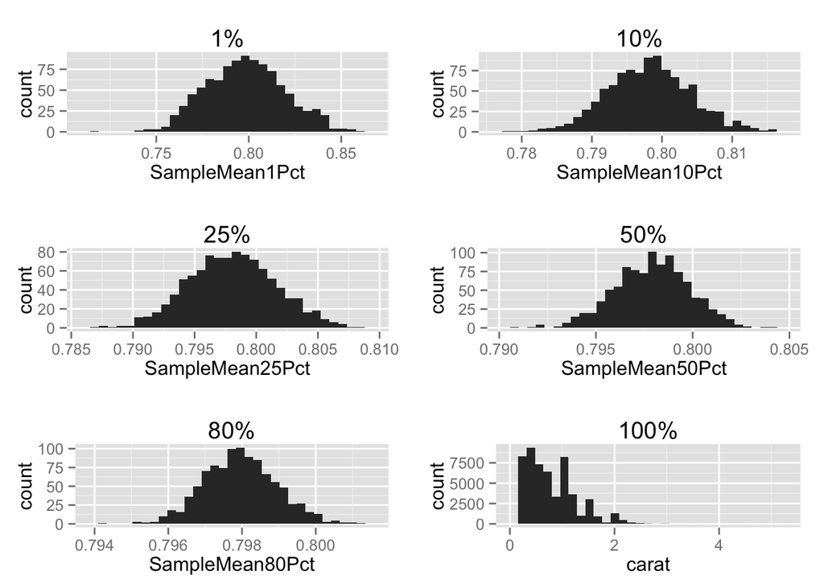

```r
#------------------------------------------------------------------------------------
loopFrame <- list()
i <- 1
for(j in 1:ncol(loopMeans)){
  loopFrame[[j]] <- loopMeans
  i <- i+1
}
loopFrame[[i]] <- diamonds
titleList = c("SampleMean1Pct","SampleMean10Pct","SampleMean25Pct","SampleMean50Pct","SampleMean80Pct","carat")
samplePlots(loopFrame,titleList,sampleSizes)
```

```r
#------------------------------------------------------------------------------------
loopStats <- data.frame(matrix(ncol=6,nrow=4))
names(loopStats) <- paste(sampleSizes*100,"%",sep="")
row.names(loopStats) <- c("MinOfMeans","MaxOfMeans","ReSampleMean","VarOfMeans")
for(i in 1:length(loopSizes)){
  for(j in 1:nrow(loopStats)){
    if(j==1){
      loopStats[j,i] <- min(loopMeans[,i])
    } else if(j==2){
      loopStats[j,i] <- max(loopMeans[,i])
    } else if(j==3){
      loopStats[j,i] <- mean(loopMeans[,i])
    } else if(j==4){
      loopStats[j,i] <- var(loopMeans[,i])
    }
  }
}
for(j in 1:nrow(loopStats)){
  if(j==1){
    loopStats[j,6] <- min(sampleStats[3,6])
  } else if(j==2){
    loopStats[j,6] <- max(sampleStats[3,6])
  } else if(j==3){
    loopStats[j,6] <- mean(sampleStats[3,6])
  } else if(j==4){
    loopStats[j,6] <- 0
  }
}
sampleStats <- rbind(sampleStats,loopStats)
print(sampleStats)
```

```
##                        1%          10%          25%          50%
## SampleMin    0.2300000000 2.000000e-01 2.000000e-01 2.000000e-01
## SampleMax    2.5100000000 3.500000e+00 4.010000e+00 4.500000e+00
## SampleMean   0.8000371058 7.929811e-01 8.002877e-01 7.966263e-01
## SampleVar    0.2279516715 2.198363e-01 2.258087e-01 2.239631e-01
## MinOfMeans   0.7154916512 7.779922e-01 7.866934e-01 7.907861e-01
## MaxOfMeans   0.8592949907 8.159047e-01 8.082618e-01 8.041554e-01
## ReSampleMean 0.7983645640 7.981887e-01 7.980587e-01 7.978875e-01
## VarOfMeans   0.0004515508 3.610426e-05 1.247392e-05 3.765121e-06
##                       80%      100%
## SampleMin    2.000000e-01 0.2000000
## SampleMax    5.010000e+00 5.0100000
## SampleMean   7.972055e-01 0.7979397
## SampleVar    2.241172e-01 0.2246867
## MinOfMeans   7.942712e-01 0.7979397
## MaxOfMeans   8.012903e-01 0.7979397
## ReSampleMean 7.979511e-01 0.7979397
## VarOfMeans   9.698643e-07 0.0000000
```

```
## stat_bin: binwidth defaulted to range/30. Use 'binwidth = x' to adjust this.
```

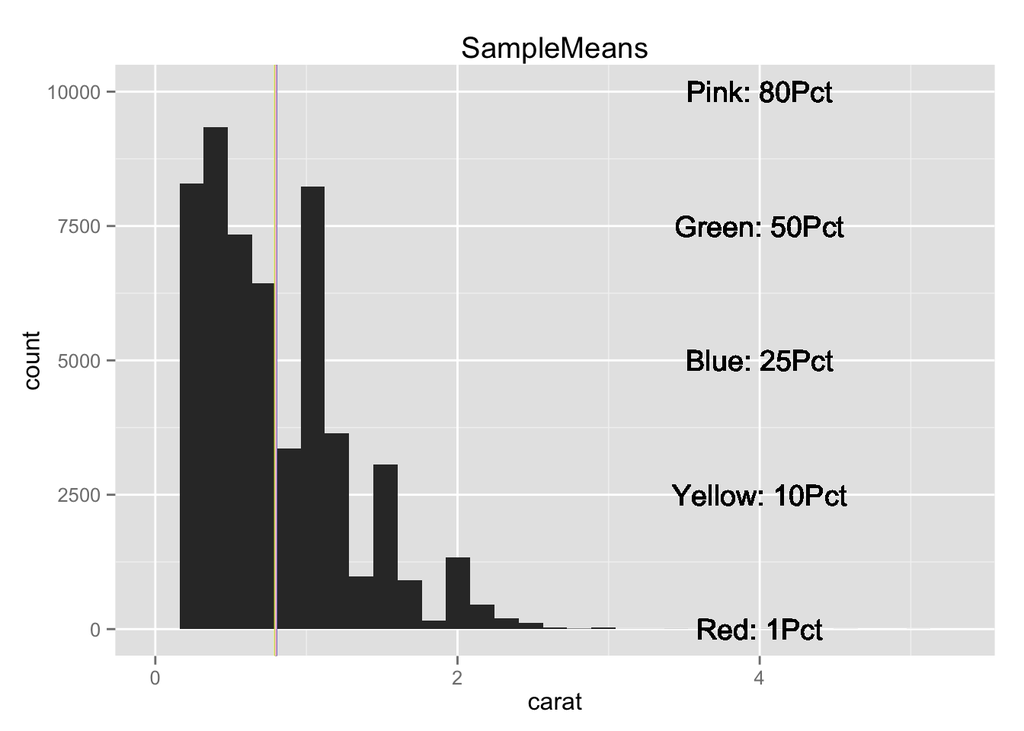

```r
#------------------------------------------------------------------------------------
sampleMeanHisto <- ggplot(diamonds,aes_string("carat")) + geom_histogram() +
  ggtitle("SampleMeans") + geom_vline(xintercept=sampleStats[3,1],color="red") +
  geom_vline(xintercept=sampleStats[3,2],color="yellow") +
  geom_vline(xintercept=sampleStats[3,3],color="blue") +
  geom_vline(xintercept=sampleStats[3,4],color="green") +
  geom_vline(xintercept=sampleStats[3,5],color="pink") +
  geom_text(aes(4,0,label="Red: 1Pct")) +
  geom_text(aes(4,2500,label="Yellow: 10Pct")) +
  geom_text(aes(4,5000,label="Blue: 25Pct")) +
  geom_text(aes(4,7500,label="Green: 50Pct")) +
  geom_text(aes(4,10000,label="Pink: 80Pct")) +
  theme(legend.position="none")
print(sampleMeanHisto)
```

```
## stat_bin: binwidth defaulted to range/30. Use 'binwidth = x' to adjust this.
```

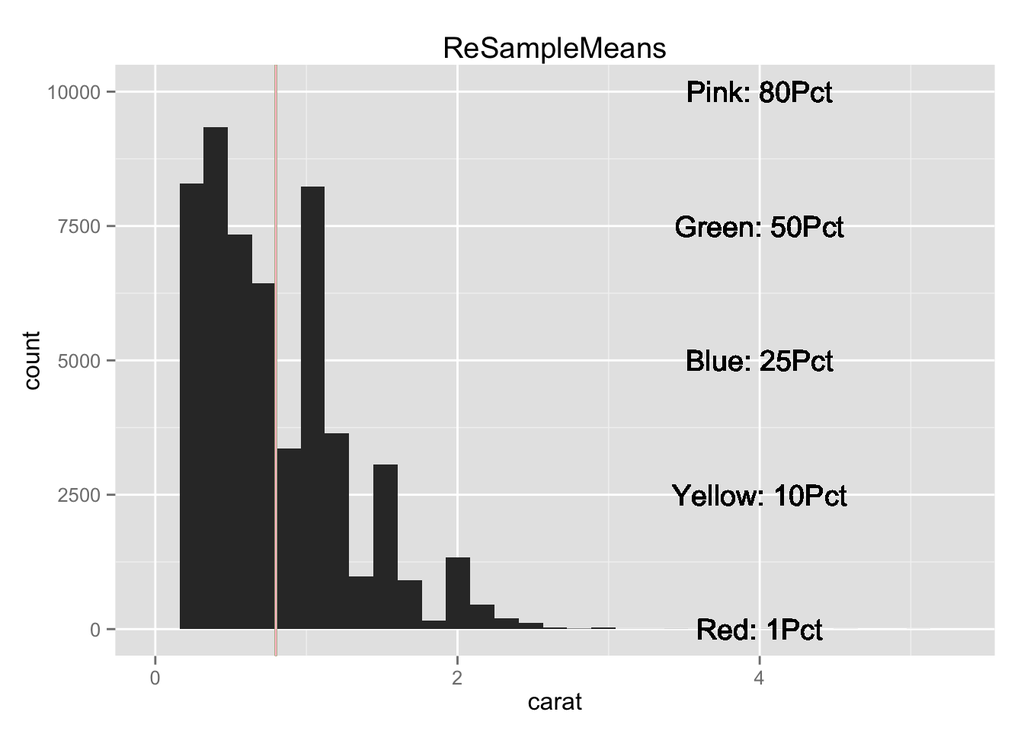

```r
#------------------------------------------------------------------------------------
reSampleMeanHisto <- ggplot(diamonds,aes_string("carat")) + geom_histogram() +
  ggtitle("ReSampleMeans") + geom_vline(xintercept=sampleStats[7,1],color="red") +
  geom_vline(xintercept=sampleStats[7,2],color="yellow") +
  geom_vline(xintercept=sampleStats[7,3],color="blue") +
  geom_vline(xintercept=sampleStats[7,4],color="green") +
  geom_vline(xintercept=sampleStats[7,5],color="pink") +
  geom_text(aes(4,0,label="Red: 1Pct")) +
  geom_text(aes(4,2500,label="Yellow: 10Pct")) +
  geom_text(aes(4,5000,label="Blue: 25Pct")) +
  geom_text(aes(4,7500,label="Green: 50Pct")) +
  geom_text(aes(4,10000,label="Pink: 80Pct")) +
  theme(legend.position="none")
print(reSampleMeanHisto)
```

faithful$eruptions

```r
sampleSizes <- c(0.01,0.10,0.25,0.50,0.80,1.00)
sampleFrame <- list()
sampleStats <- data.frame(matrix(ncol=6,nrow=4))
names(sampleStats) <- paste(sampleSizes*100,"%",sep="")
row.names(sampleStats) <- c("SampleMin","SampleMax","SampleMean","SampleVar")
for(i in 1:ncol(sampleStats)){
  sampleFrame[[i]] <- faithful[sample(nrow(faithful),sampleSizes[i]*nrow(faithful)),]
  for(j in 1:nrow(sampleStats)){
    if(j==1){
      sampleStats[j,i] <- min(sampleFrame[[i]]$eruptions)
    } else if(j==2){
      sampleStats[j,i] <- max(sampleFrame[[i]]$eruptions)
    } else if(j==3){
      sampleStats[j,i] <- mean(sampleFrame[[i]]$eruptions)
    } else if(j==4){
      sampleStats[j,i] <- var(sampleFrame[[i]]$eruptions)
    }
  }
}
print(sampleStats)
```

```
##                  1%      10%      25%      50%      80%     100%
## SampleMin  2.400000 1.667000 1.733000 1.600000 1.600000 1.600000
## SampleMax  4.433000 5.033000 4.933000 5.100000 5.000000 5.100000
## SampleMean 3.416500 3.749407 3.521809 3.609051 3.534825 3.487783
## SampleVar  2.066545 1.151400 1.399117 1.260277 1.295207 1.302728
```

```r
#------------------------------------------------------------------------------------
samplePlots(sampleFrame,rep("eruptions",6),sampleSizes)
```

[output not shown]

```
## stat_bin: binwidth defaulted to range/30. Use 'binwidth = x' to adjust this.
```

[output not shown]

```r
#------------------------------------------------------------------------------------
loopSizes <- sampleSizes[sampleSizes<1.00]
loopMeans <- data.frame(matrix(ncol=5,nrow=1000))
names(loopMeans) <- c("SampleMean1Pct","SampleMean10Pct","SampleMean25Pct","SampleMean50Pct","SampleMean80Pct")
for(i in 1:length(loopSizes)){
  for(j in 1:1000){
    sampleFrame <- faithful[sample(nrow(faithful),loopSizes[i]*nrow(faithful)),]
    loopMeans[j,i] <- mean(sampleFrame$eruptions)
  }
}
print(loopMeans)
```

```
##      SampleMean1Pct SampleMean10Pct SampleMean25Pct SampleMean50Pct
## 1            4.4085        3.706815        3.441868        3.510515
## 2            4.5165        3.291296        3.574279        3.525228
## 3            3.5830        3.408519        3.415162        3.435471
## 4            2.8415        3.401778        3.265441        3.478059
## 5            4.4750        3.555481        3.552662        3.425456
## 6            1.7750        3.337037        3.661206        3.454162
## 7            4.6000        4.232593        3.359529        3.480147
## 8            3.2670        3.455519        3.347500        3.375235
## 9            3.0750        3.533926        3.378162        3.544603
## 10           4.1500        3.424667        3.538426        3.487221
## 11           3.4250        3.716000        3.491382        3.463235
## 12           2.1420        3.537704        3.633000        3.479147
## 13           3.1335        3.377778        3.507103        3.554750
## 14           3.5000        3.265333        3.596809        3.473625
```

[output cut: 1987 more lines]

```
## stat_bin: binwidth defaulted to range/30. Use 'binwidth = x' to adjust this.
## stat_bin: binwidth defaulted to range/30. Use 'binwidth = x' to adjust this.
## stat_bin: binwidth defaulted to range/30. Use 'binwidth = x' to adjust this.
## stat_bin: binwidth defaulted to range/30. Use 'binwidth = x' to adjust this.
```

```
## stat_bin: binwidth defaulted to range/30. Use 'binwidth = x' to adjust this.
## stat_bin: binwidth defaulted to range/30. Use 'binwidth = x' to adjust this.
```

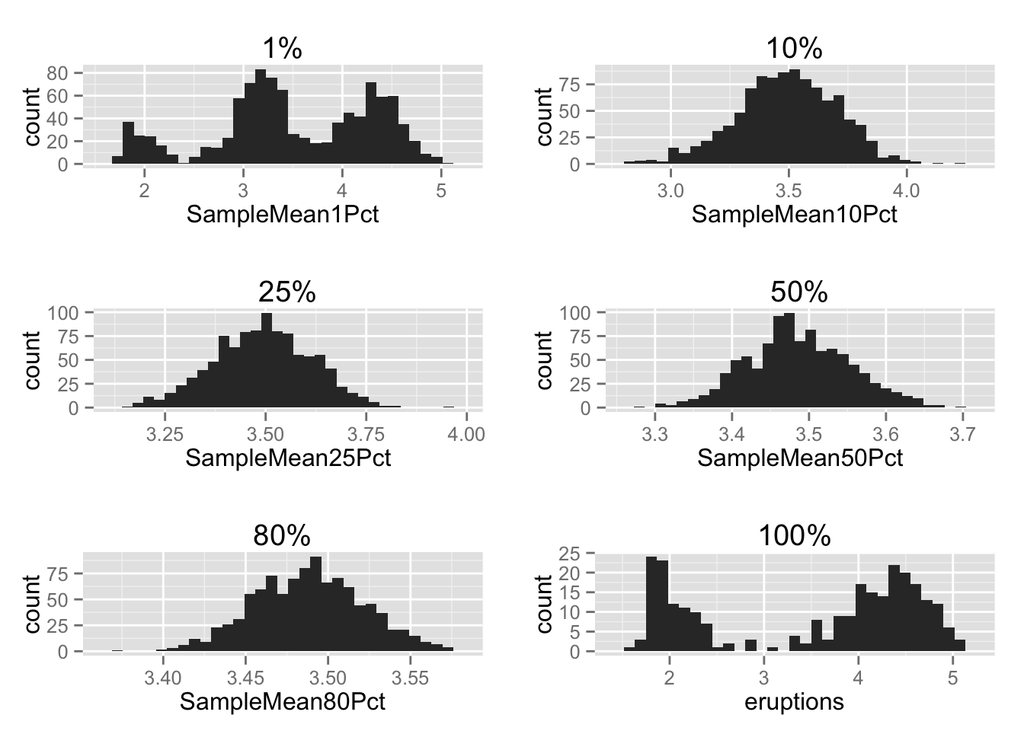

```r
#------------------------------------------------------------------------------------
loopFrame <- list()
i <- 1
for(j in 1:ncol(loopMeans)){
  loopFrame[[j]] <- loopMeans
  i <- i+1
}
loopFrame[[i]] <- faithful
titleList = c("SampleMean1Pct","SampleMean10Pct","SampleMean25Pct","SampleMean50Pct","SampleMean80Pct","eruptions")
samplePlots(loopFrame,titleList,sampleSizes)
```

```r
#------------------------------------------------------------------------------------
loopStats <- data.frame(matrix(ncol=6,nrow=4))
names(loopStats) <- paste(sampleSizes*100,"%",sep="")
row.names(loopStats) <- c("MinOfMeans","MaxOfMeans","ReSampleMean","VarOfMeans")
for(i in 1:length(loopSizes)){
  for(j in 1:nrow(loopStats)){
    if(j==1){
      loopStats[j,i] <- min(loopMeans[,i])
    } else if(j==2){
      loopStats[j,i] <- max(loopMeans[,i])
    } else if(j==3){
      loopStats[j,i] <- mean(loopMeans[,i])
    } else if(j==4){
      loopStats[j,i] <- var(loopMeans[,i])
    }
  }
}
for(j in 1:nrow(loopStats)){
  if(j==1){
    loopStats[j,6] <- min(sampleStats[3,6])
  } else if(j==2){
    loopStats[j,6] <- max(sampleStats[3,6])
  } else if(j==3){
    loopStats[j,6] <- mean(sampleStats[3,6])
  } else if(j==4){
    loopStats[j,6] <- 0
  }
}
sampleStats <- rbind(sampleStats,loopStats)
print(sampleStats)
```

```
##                     1%      10%        25%         50%         80%
## SampleMin    2.4000000 1.667000 1.73300000 1.600000000 1.600000000
## SampleMax    4.4330000 5.033000 4.93300000 5.100000000 5.000000000
## SampleMean   3.4165000 3.749407 3.52180882 3.609051471 3.534824885
## SampleVar    2.0665445 1.151400 1.39911735 1.260277116 1.295206738
## MinOfMeans   1.6750000 2.831963 3.16907353 3.281948529 3.374940092
## MaxOfMeans   5.0165000 4.232593 3.96817647 3.699735294 3.575470046
## ReSampleMean 3.5035170 3.490437 3.49252901 3.486500926 3.488301829
## VarOfMeans   0.6568303 0.045397 0.01471415 0.004579655 0.001101379
##                  100%
## SampleMin    1.600000
## SampleMax    5.100000
## SampleMean   3.487783
## SampleVar    1.302728
## MinOfMeans   3.487783
## MaxOfMeans   3.487783
## ReSampleMean 3.487783
## VarOfMeans   0.000000
```

```
## stat_bin: binwidth defaulted to range/30. Use 'binwidth = x' to adjust this.
```

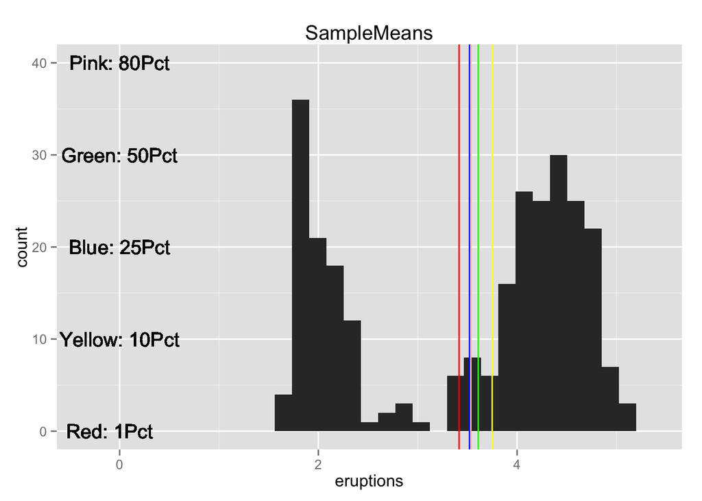

```r
#------------------------------------------------------------------------------------
sampleMeanHisto <- ggplot(faithful,aes_string("eruptions")) + geom_histogram() +
  ggtitle("SampleMeans") + geom_vline(xintercept=sampleStats[3,1],color="red") +
  geom_vline(xintercept=sampleStats[3,2],color="yellow") +
  geom_vline(xintercept=sampleStats[3,3],color="blue") +
  geom_vline(xintercept=sampleStats[3,4],color="green") +
  geom_vline(xintercept=sampleStats[3,5],color="pink") +
  geom_text(aes(-0.1,0,label="Red: 1Pct")) +
  geom_text(aes(0,10,label="Yellow: 10Pct")) +
  geom_text(aes(0,20,label="Blue: 25Pct")) +
  geom_text(aes(0,30,label="Green: 50Pct")) +
  geom_text(aes(0,40,label="Pink: 80Pct")) +
  theme(legend.position="none")
print(sampleMeanHisto)
```

```
## stat_bin: binwidth defaulted to range/30. Use 'binwidth = x' to adjust this.
```

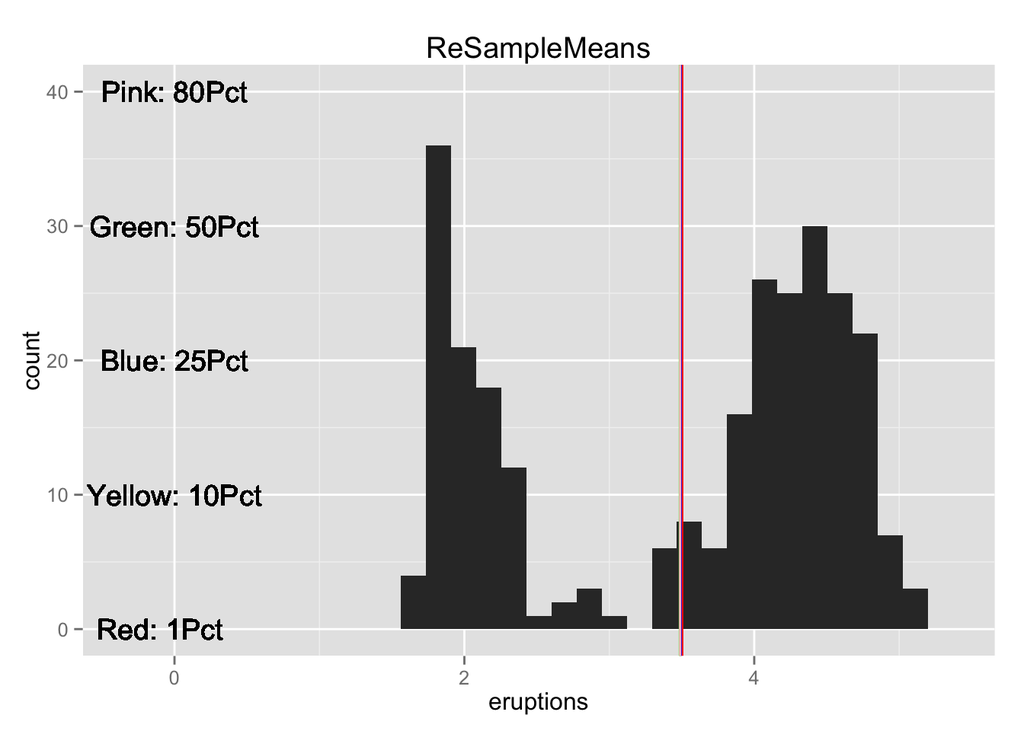

```r
#------------------------------------------------------------------------------------
reSampleMeanHisto <- ggplot(faithful,aes_string("eruptions")) + geom_histogram() +
  ggtitle("ReSampleMeans") + geom_vline(xintercept=sampleStats[7,1],color="red") +
  geom_vline(xintercept=sampleStats[7,2],color="yellow") +
  geom_vline(xintercept=sampleStats[7,3],color="blue") +
  geom_vline(xintercept=sampleStats[7,4],color="green") +
  geom_vline(xintercept=sampleStats[7,5],color="pink") +
  geom_text(aes(-0.1,0,label="Red: 1Pct")) +
  geom_text(aes(0,10,label="Yellow: 10Pct")) +
  geom_text(aes(0,20,label="Blue: 25Pct")) +
  geom_text(aes(0,30,label="Green: 50Pct")) +
  geom_text(aes(0,40,label="Pink: 80Pct")) +
  theme(legend.position="none")
print(reSampleMeanHisto)
```

Question 9:

This code demonstrates two key phenomena regarding distributions and sample sizes. First, we see that as sample size increases, the distribution and summary statistics of that sample approach the distribution and summary statistics of the entire dataset. This point is demonstrated by the plots and summary statistics generated in Questions 1 and 2, as the output generated here for each sample size approaches that of the entire dataset as our sample size increases. We also see in Question 4 that as sample size increases, the distribution of sample means grows tighter and tighter about the mean of the entire dataset.

Next, Questions 3 through 7 demonstrate that as we take repeated samples of a given size, the mean of those sample means quickly approaches the mean of the entire dataset, for each sample size. Examining the summary statistics table from Question 5, we see much greater variance between the sample means than between the resample means, even at just the 1% sample size. We also see that the resample means plotted on the histogram from Question 7 are much tighter about the mean of the entire dataset than the sample means plotted on the histogram from Question 6.

In sum, this code demonstrates two ways to generate reliable summary statistics for a dataset. First, we may simply take relatively large samples. If taking large samples, however, is for any reason impossible, we may also take many repeated small samples. As demonstrated here, both sampling methods generate sample means that are reasonably close to the mean of the entire dataset.